# A3: SPL Library Checkouts

### Introduction

**An introduction of the data and a description of the trends/books/items you are choosing to analyze (and why!)**

To be honest, I chose my data set entirely based on whichever one had the smallest file size, which was the data set with items checked out at least 10x a month from 2017 to 2023 (229 MB.) The trend I chose was extremely broad and not too niche, so I definitely had the flexibility to choose any of the three listed data sets. For this project, the trend I analyzed was E-book popularity over the years compared to book popularity. I was interested in this question because from personal experience of volunteering at a library during the pandemic, I knew that E-books had a major moment in 2020, and was wondering if that was just a local trend or widely applicable.

### Summary Information

**Write a summary paragraph of findings that includes the 5 values calculated from your summary information R script**

To determine the trends in E-book popularity over time, there were a few questions I knew I had to answer for sure. These basic summary statistics included:

1. What is the total number of E-books checked out in each year listed in the dataframe? Print books?
2. Has there been a year(s) where E-books were checked out more than print books?
3. What is the average number of E-books checked out? Books?

From the results of these discussion questions, the keynote was that E-books became largely more checked out than books over time. Since 2020, E-books have had more checkouts than books, positively skewing the data. From this conclusion, I found two more questions to help me better understand this trend:

4. What year had the most E-book checkouts?
5. What is the ratio of E-book / Book Checkouts in each year?

### The Dataset

All of the data sets that were provided for this assignment were published by the Seattle Public Library (SPL.) Since this is a checkout database, it is most probable that the data used in these data sets is collected and compiled automatically whenever a book is checked out of the SPL system. One ethical concern that I have is the possibility of data being collected without informed consent. The library that I used to volunteer at combated this by allowing those who are registering for a new library card to opt out of data collection at the time of registration. I am unsure if this is a common practice or if SPL follows this guideline as well.

As I’ve mentioned previously, the trend that I chose was **very** broad. I didn’t have to worry about the limitations of this data set either for that reason. The only types of books that I considered in my project were books and e-books, both of which were present in this data set. I was additionally interested in the trends of E-book vs. book popularity from pre-pandemic, pandemic, and post-pandemic time frames. The data set spans from 2017 to 2023, so I didn’t have to consider this possible constraint either. The columns of this data set that I was interested in was the type of book (PRINT, EBOOK), the the checkout year for each item, and the number of checkouts. Then, the parameters (overall data description) that I analyzed was trends in book checkout and trends in e-book checkout. Overall, I am content with this data set and didn’t find any shortcomings in it that could weaken my analysis.

### First Trends Over Time Chart

**Include a chart. Make sure to describe why you included the chart, and what patterns emerged.**

This chart displays the trend in the number of E-book checkouts over time versus the number of book checkouts from the years of 2017 to 2023. In the graph below, we see that E-books rose in checkout frequency steadily from 2017 to 2020. Additionally, from 2019 to 2020, books faced a steep decline in checkout frequency. The sharp decline in both books and E-books from 2022 to 2023 can be attributed to the fact that there is comparatively less checkout data for 2023 than other years, since the year has barely started. I included this chart because it is the simplest display to visualize the trend I was interested in. The chart is readable and pleasing to the eye because of its simplicity. It uses minimal information while still being able to project the trend I’m interested in.

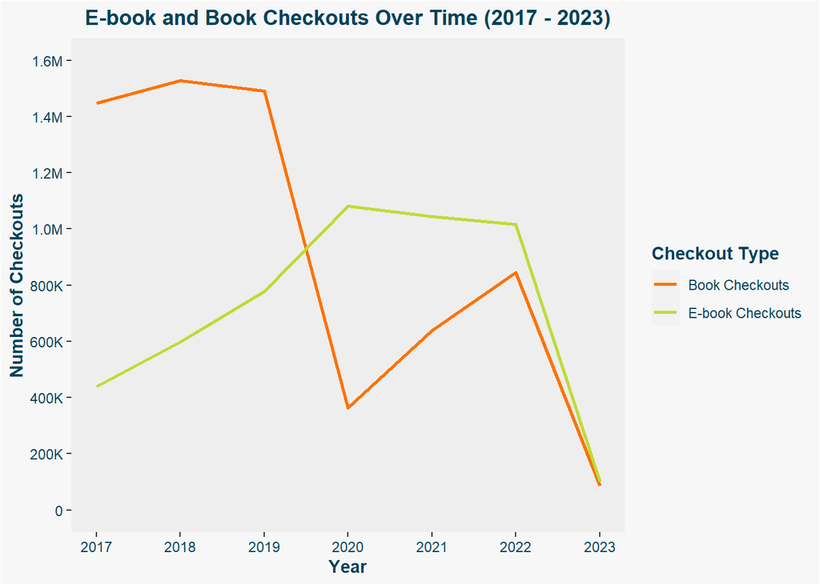

### Second Trends Over Time Chart

**Include a chart. Make sure to describe why you included the chart, and what patterns emerged.**

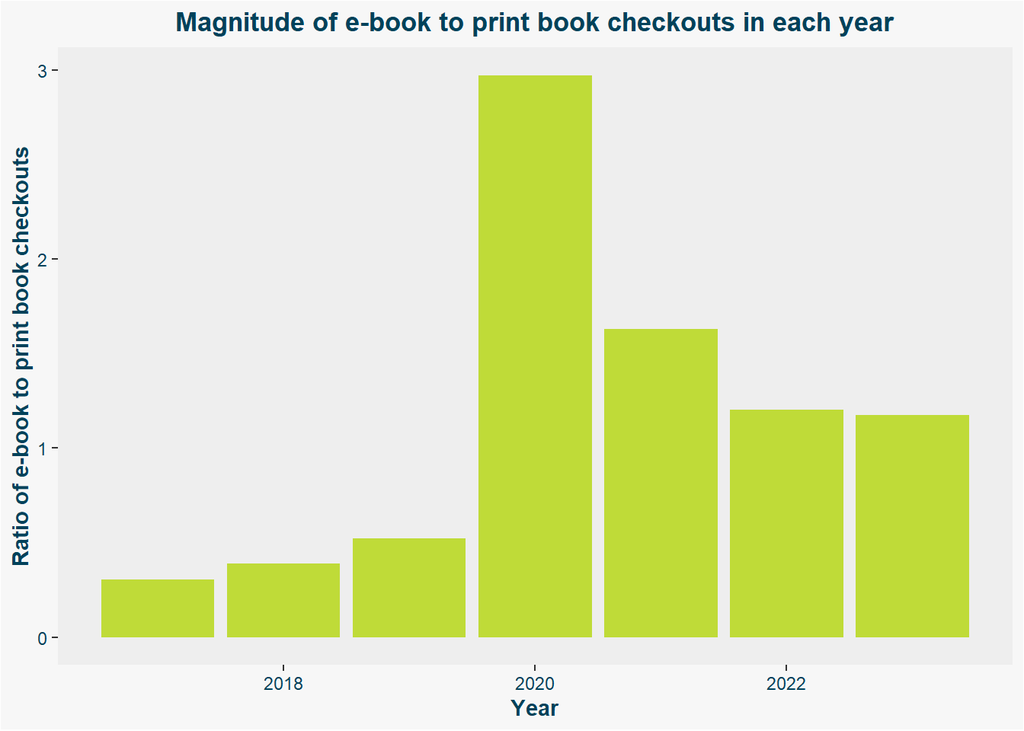

### Third Data Visualization

I included this chart to visualize whether E-books or books are more frequently checked out on average. The results indicate that E-books are checked out more frequently checked out. This chart is a skewed representation of the trend due to a major outlier in E-book checkout frequency in 2020. I think that the difference in the averages would have been much more subtle if the data set covered more years past 2017. However, for the purposes of this project, I am satisfied with the inclusion of this chart. Ultimately, it is a simple and humanly designed chart that conveys key information from this data analysis.

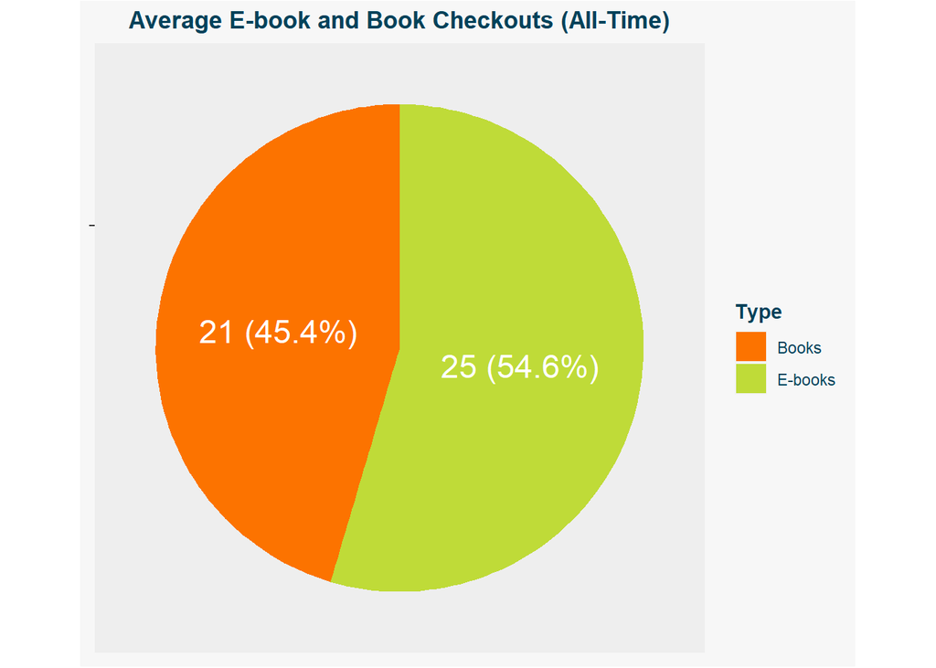